# Tema 3

Jose Manuel Valdeolmillos

8 de agosto de 2016

## Ejercicio 1

Utiliza los datos “Arthritis” (paquete “vcd”) sobre un ensayo clínico de doble ciego que investiga un nuevo tratamiento para la artritis reumatoide. Tenemos información de 84 observaciones de 5 variables: la identificación del paciente (ID), el tratamiento (Treatment: Placebo, Treated), el sexo (Sex: Female, Male), la edad (Age) y la mejoría (Improved: None, Some, Marked). Para el grupo tratamiento, queremos comparar las edades de los pacientes que no mostraron mejoría con los que sí tuvieron una marcada mejoría.

#### Realiza pruebas paramétricas, no paramétricas y robustas. Interpreta y compara los resultados.

```r
library(vcd)
attach(Arthritis)
head(Arthritis)
```

```
##   ID Treatment  Sex Age Improved
## 1 57   Treated Male  27     Some
## 2 46   Treated Male  29     None
## 3 77   Treated Male  30     None
## 4 17   Treated Male  32   Marked
## 5 36   Treated Male  46   Marked
## 6 23   Treated Male  58   Marked
```

```r
library(ggplot2)

# Comparar edades de pacientes sin mejoría con las de mejoría
mejoria <- subset(Arthritis, Improved == "Marked" | Improved == "None")
mejoria$Improved <- droplevels(mejoria$Improved)
detach(Arthritis)

shapiro.test(mejoria$Age)
```

```
##
##  Shapiro-Wilk normality test
##
## data:  mejoria$Age
## W = 0.93324, p-value = 0.001059
```

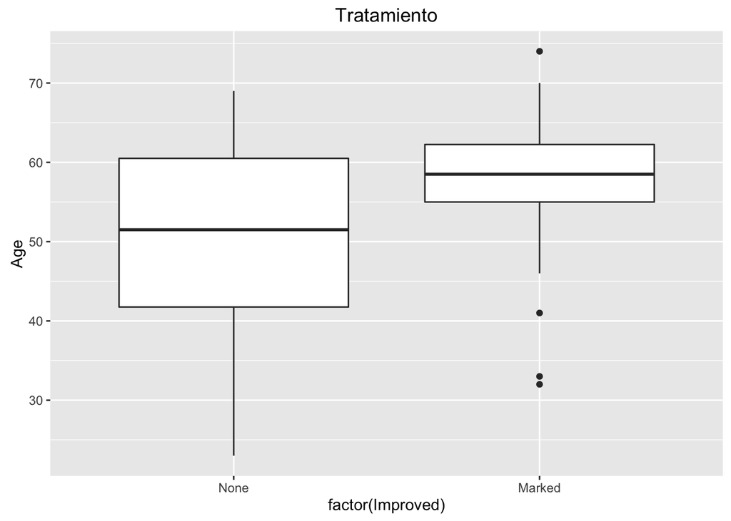

```r
ggplot(mejoria, aes(factor(Improved), Age)) + geom_boxplot() + labs(title = "Tratamiento")
```

```r
# No sigue una distribución normal.
# Existen Outliers.
```

#### pruebas paramétricas (suponemos Normalidad y homocedasticidad)

Hipotesis Nula <- Son iguales. Hipotesis alternativa <- son diferentes.

```r
t.test(Age ~ Improved, data = mejoria)
```

```
##
##  Welch Two Sample t-test
##
## data:  Age by Improved
## t = -2.6594, df = 67.007, p-value = 0.009784
## alternative hypothesis: true difference in means is not equal to 0
## 95 percent confidence interval:
##  -12.795753  -1.823295
## sample estimates:
##   mean in group None mean in group Marked
##             49.69048             57.00000
```

```r
# p-valor < 0.05. Tenemos evidencia en los datos para afirmar con un 95% de confianza
# que las edades no son iguales en ambos grupos. La edad media en el
# grupo de mejora evidente es superior (la media) que en el de ninguna mejora.
```

#### pruebas No Parametricas

Hipotesis Nula <- Son iguales. Hipotesis alternativa <- son diferentes.

```r
wilcox.test(Age ~ Improved, data = mejoria)
```

```
##
##  Wilcoxon rank sum test with continuity correction
##
## data:  Age by Improved
## W = 394.5, p-value = 0.02056
## alternative hypothesis: true location shift is not equal to 0
```

```r
# p-valor < 0.05. Tenemos evidencia en los datos para afirmar con un 95% de confianza
# que las edades no son iguales en ambos grupos. La edad media en el
# grupo de mejora evidente es superior (la media) que en el de ninguna mejora.
```

#### pruebas Robustas

Hipotesis Nula <- Son iguales. Hipotesis alternativa <- son diferentes.

```r
library(DescTools)
YuenTTest(formula = Age ~ Improved, data = mejoria)
```

```
##
##  Yuen Two Sample t-test
##
## data:  Age by Improved
## t = -2.6415, df = 34.496, trim = 0.200, p-value = 0.01232
## alternative hypothesis: true difference in trimmed means is not equal to 0
## 95 percent confidence interval:
##  -12.526315  -1.636079
## sample estimates:
##   trimmed mean in group None trimmed mean in group Marked
##                     51.30769                     58.38889
```

```r
# p-valor < 0.05. Tenemos evidencia en los datos para afirmar con un 95% de confianza que las edades no son iguales en ambos grupos.
# La edad media en el grupo de mejora evidente es superior (la media) que en el de ninguna mejora.
```

## Ejercicio 2

Utiliza los datos “immer” (paquete “MASS”) sobre el rendimiento de la cebada en los años 1931 y 1932 en un mismo campo de recolección. Comprueba mediante pruebas paramétricas, no paramétricas y robustas si han cambiado los valores medios de la producción de cebada. Realiza pruebas paramétricas, no paramétricas y robustas. Interpreta y compara los resultados.

```r
library(MASS)
attach(immer)
head(immer)
```

```
##   Loc Var    Y1    Y2
## 1  UF   M  81.0  80.7
## 2  UF   S 105.4  82.3
## 3  UF   V 119.7  80.4
## 4  UF   T 109.7  87.2
## 5  UF   P  98.3  84.2
## 6   W   M 146.6 100.4
```

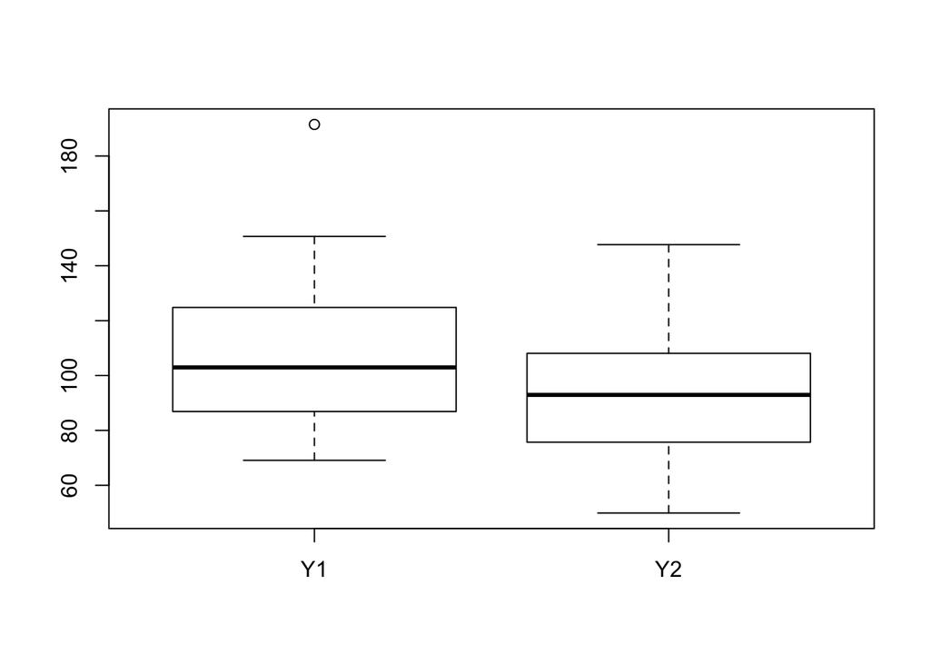

```r
# En esta caso son muestras relacionadas.
cosecha <- immer[,c("Y1", "Y2")]
boxplot(cosecha)
```

```r
# Se aprecia la existencia de outliers.

# hacemos la preba de normalidad
shapiro.test(cosecha$Y1)
```

```
##
##  Shapiro-Wilk normality test
##
## data:  cosecha$Y1
## W = 0.92973, p-value = 0.04829
```

```r
# No sigue una distribución normal.
shapiro.test(cosecha$Y2)
```

```
##
##  Shapiro-Wilk normality test
##
## data:  cosecha$Y2
## W = 0.97567, p-value = 0.7026
```

```r
# Sigue una distribución normal
```

#### PRUEBAS PARAMÉTRICAS (suponemos Normalidad y homocedasticidad). Hay relación.

Hipotesis Nula <- Poseen el mismo peso medio. En cada campo por año. Hipotesis alternativa <- No poseen el mismo peso medio (Y1 fue mayor que Y2).

```r
(t1 <- t.test(cosecha$Y1, cosecha$Y2, paired = T, alternative = "greater"))
```

```
##
##  Paired t-test
##
## data:  cosecha$Y1 and cosecha$Y2
## t = 3.324, df = 29, p-value = 0.001206
## alternative hypothesis: true difference in means is greater than 0
## 95 percent confidence interval:
##  7.778893      Inf
## sample estimates:
## mean of the differences
##                15.91333
```

```r
# p-valor < 0.05: Se acepta la hipótesis alternativa. El año Y2 obtuvo un peso menor a Y1
```

#### PRUEBAS NO PARAMÉTRICAS

Hipotesis Nula <- Poseen el mismo peso medio. En cada campo por año. Hipotesis alternativa <- No poseen el mismo peso medio (Y1 fue mayor que Y2).

```r
(t1 <- wilcox.test(cosecha$Y1, cosecha$Y2, paired = T, alternative = "greater"))
```

```
##
##  Wilcoxon signed rank test with continuity correction
##
## data:  cosecha$Y1 and cosecha$Y2
## V = 368.5, p-value = 0.002659
## alternative hypothesis: true location shift is greater than 0
```

```r
# p-valor < 0.05: Se acepta la hipótesis alternativa. El año Y2 obtuvo un peso menor a Y1
```

#### PRUEBAS ROBUSTAS (Existen outliers en este caso)

Hipotesis Nula <- Poseen el mismo peso medio. En cada campo por año. Hipotesis alternativa <- No poseen el mismo peso medio (Y1 fue mayor que Y2).

```r
library(WRS2)

(tC <- yuend(x = cosecha$Y1, y = cosecha$Y2))
```

```
## Call:
## yuend(x = cosecha$Y1, y = cosecha$Y2)
##
## Test statistic: 2.2117 (df = 17), p-value = 0.04097
##
## Trimmed mean difference:  13.73333
## 95 percent confidence interval:
## 0.6327     26.834
```

```r
# p-valor < 0.05: Se acepta la hipótesis alternativa. El año Y2 obtuvo un peso menor a Y1

detach(immer)
```

## Ejercicio 3

Utiliza los datos “PlantGrowth” que indica el peso seco de 30 lotes de plantas donde cada una recibió 1 de 3 tratamientos diferentes. Queremos determinar si el peso del lote es similar para los distintos grupos. Realiza pruebas paramétricas, no paramétricas y robustas. Interpreta y compara los resultados.

```r
attach(PlantGrowth)
head(PlantGrowth)
```

```
##   weight group
## 1   4.17  ctrl
## 2   5.58  ctrl
## 3   5.18  ctrl
## 4   6.11  ctrl
## 5   4.50  ctrl
## 6   4.61  ctrl
```

```r
levels(PlantGrowth$group)
```

```
## [1] "ctrl" "trt1" "trt2"
```

```r
table(PlantGrowth$group)
```

```
##
## ctrl trt1 trt2
##   10   10   10
```

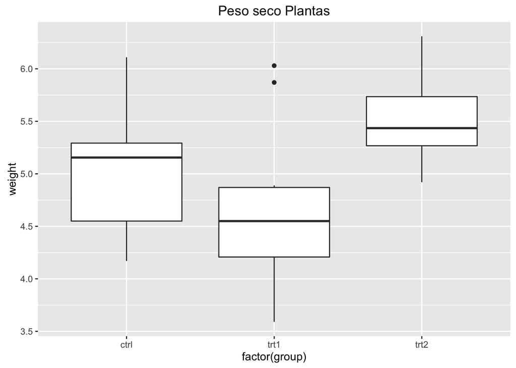

```r
ggplot(PlantGrowth, aes(factor(group), weight)) + geom_boxplot() + labs(title = "Peso seco Plantas")
```

```r
# Comentar que son variables independientes, n < 30 (muestra pequeña)
# Existen outliers y se puede apreciar también en el gráfico que hay diferencia en los pesos entre los 3 grupos.
```

#### PRUEBAS PARAMÉTRICAS

Hipotesis Nula <- Todas las medias son iguales (pesos similares, pesos medios similares) Hipotesis alternativa <- Existe alguna media diferente.

```r
m1 <- aov(weight ~ group, data = PlantGrowth)
summary(m1)
```

```
##             Df Sum Sq Mean Sq F value Pr(>F)
## group        2  3.766  1.8832   4.846 0.0159 *
## Residuals   27 10.492  0.3886
## ---
## Signif. codes:  0 '***' 0.001 '**' 0.01 '*' 0.05 '.' 0.1 ' ' 1
```

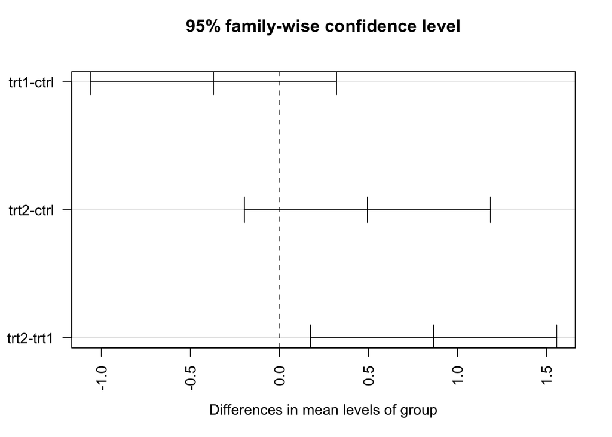

```r
# Existen diferencias entre los pesos de los lotes, aunque no muy significativas. p-valor = 0.02
# Marca además una estrella.
# La moyor diferencia aparece entre tratamiento 2 y tratamiento 1 que fue el que aportó peor resultado en cuanto a peso (el de menor peso).

## Pruebas post hoc
plot(TukeyHSD(m1), las=2)
```

```r
TukeyHSD(m1)
```

```
##   Tukey multiple comparisons of means
##     95% family-wise confidence level
##
## Fit: aov(formula = weight ~ group, data = PlantGrowth)
##
## $group
##             diff        lwr       upr     p adj
## trt1-ctrl -0.371 -1.0622161 0.3202161 0.3908711
## trt2-ctrl  0.494 -0.1972161 1.1852161 0.1979960
## trt2-trt1  0.865  0.1737839 1.5562161 0.0120064
```

```r
# La mayor diferencia aparece entre tratamiento 2 y tratamiento 1 que fue el que aportó peor resultado en cuanto a peso (el de menor peso).
```

#### PRUEBAS NO PARAMÉTRICAS.

Hipotesis Nula <- Todas las medias son iguales (pesos similares, pesos medios similares) Hipotesis alternativa <- Existe alguna media diferente.

```r
kruskal.test(weight ~ group, data = PlantGrowth)
```

```
##
##  Kruskal-Wallis rank sum test
##
## data:  weight by group
## Kruskal-Wallis chi-squared = 7.9882, df = 2, p-value = 0.01842
```

```r
# Existen diferencias entre los pesos de los lotes, aunque no muy significativas. p-valor = 0.02

## Pruebas post hoc
require(PMCMR)
posthoc.kruskal.nemenyi.test(x = weight, g = group, data = PlantGrowth, dist = "Chisquare")
```

```
##
##  Pairwise comparisons using Nemenyi-test with Chi-squared
##                        approximation for independent samples
##
## data:  weight and group
##
##      ctrl  trt1
## trt1 0.535 -
## trt2 0.240 0.019
##
## P value adjustment method: none
```

```r
# De nuevo muestra que entre trt1 y trt2 existe mayor diferencia.
```

#### PRUEBAS ROBUSTAS.

Hipotesis Nula <- Todas las medias son iguales (pesos similares, pesos medios similares) Hipotesis alternativa <- Existe alguna media diferente.

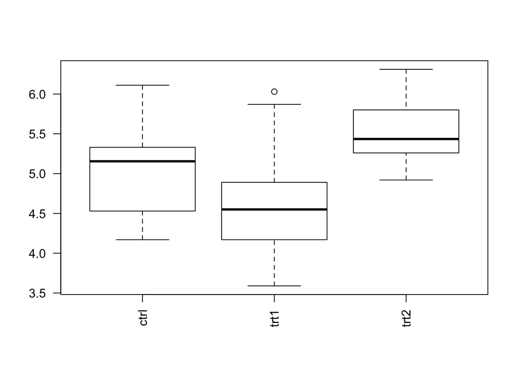

```r
boxplot(weight ~ group, data = PlantGrowth, las=2)
```

```r
library(WRS2)
t1way(weight ~ group, data = PlantGrowth)
```

```
## Call:
## t1way(formula = weight ~ group, data = PlantGrowth)
##
## Test statistic: 8.2818
## Degrees of Freedom 1: 2
## Degrees of Freedom 2: 9.64
## p-value: 0.00807
```

```r
# Rechazamos H0. Existen diferencias entre los pesos de los lotes. p-valor = 0.008

## Pruebas post hoc
lincon(weight ~ group, data = PlantGrowth)
```

```
## Call:
## lincon(formula = weight ~ group, data = PlantGrowth)
##
##                 psihat ci.lower ci.upper p.value
## ctrl vs. trt1  0.44500 -0.31513  1.20513 0.12801
## ctrl vs. trt2 -0.46667 -1.16501  0.23168 0.08453
## trt1 vs. trt2 -0.91167 -1.54306 -0.28027 0.00236
```

```r
# La mayor diferencia se detecta entre trt1 y trt2.
detach(PlantGrowth)
```

## Ejercicio 4

Utiliza los datos “WeightLoss” del paquete “car” sobre la pérdida de peso y los valores de autoestima durante tres meses en 34 sujetos, para tres grupos: “control”, “dieta” y “dieta + ejercicio”. Queremos evaluar si en los grupos de tratamiento (poner en un mismo grupo a sujetos con “dieta” o “dieta + ejercicio”) ha aumentado el nivel de autoestima a lo largo del tiempo. Realice pruebas paramétricas, no paramétricas y robustas para su contraste. Utilice la función “rp.outlier” del paquete “rapportools” para evaluar la presencia de outliers en las variables de estudio.

```r
library(car)
library(reshape)
attach(WeightLoss)
head(WeightLoss)
```

```
##     group wl1 wl2 wl3 se1 se2 se3
## 1 Control   4   3   3  14  13  15
## 2 Control   4   4   3  13  14  17
## 3 Control   4   3   1  17  12  16
## 4 Control   3   2   1  11  11  12
## 5 Control   5   3   2  16  15  14
## 6 Control   6   5   4  17  18  18
```

```r
# Separamos peso y estado de animo y reindexamos
data <- subset(WeightLoss, group != "Control")
# Vamos a detectar la existencia de outliers en las diferentes columnas.
library(rapportools)
rp.outlier(data$wl1)
```

```
## integer(0)
```

```r
rp.outlier(data$wl2)
```

```
## integer(0)
```

```r
rp.outlier(data$wl3)
```

```
## integer(0)
```

```r
rp.outlier(data$se1)
```

```
## integer(0)
```

```r
rp.outlier(data$se2)
```

```
## integer(0)
```

```r
rp.outlier(data$se3)
```

```
## [1] 11
```

```r
# Existencia en outlier valor 11 en la columna de datos se3.

dataW <- cbind(ID = as.factor(1:22),data[,2:4])
rownames(dataW) <- NULL
dataS <- cbind(ID = as.factor(1:22),data[,5:7])
rownames(dataS)<- NULL
# pasamos las columnas de wl como una columna variable.
dataLS<-melt( dataS, id.vars = "ID", measure.vars = 2:4)
dataLS <- dataLS[order(dataLS$ID),]
dataLW<-melt( dataW, id.vars = "ID", measure.vars = 2:4)
dataLW<- dataLW[order(dataLW$ID),]
row.names(dataLS)<-NULL
row.names(dataLW)<-NULL
```

#### PRUEBAS PARAMETRICAS

Hipotesis Nula <- Todas las medias son iguales (no existe aumento) Hipotesis alternativa <- Existe alguna media diferente.

```r
library(ez)
library(WRS2)
ezANOVA(data=dataLS, dv=value, wid=ID, within = variable)
```

```
## $ANOVA
##     Effect DFn DFd        F           p p<.05       ges
## 2 variable   2  42 28.11523 1.78265e-08     * 0.2935338
##
## $`Mauchly's Test for Sphericity`
##     Effect         W           p p<.05
## 2 variable 0.5345165 0.001903757     *
##
## $`Sphericity Corrections`
##     Effect       GGe       p[GG] p[GG]<.05       HFe        p[HF]
## 2 variable 0.6823687 1.94791e-06         * 0.7136197 1.225223e-06
##   p[HF]<.05
## 2         *
```

```r
# Primera línea p-valor < 0.05. Rechazamos igualdad de medias. Hay diferencia.
# La prueba de esfericidad dice que también deberíamos rechazarla (Hip Nula).

# Vamos a ver entre que medidas hay diferencia.
aggregate(value~variable, dataLS, mean)
```

```
##   variable    value
## 1      se1 15.00000
## 2      se2 13.54545
## 3      se3 16.81818
```

```r
with(dataLS, pairwise.t.test(value, variable, p.adjust.method = "bonferroni", paired = T))
```

```
##
##  Pairwise comparisons using paired t tests
##
## data:  value and variable
##
##     se1     se2
## se2 0.0023  -
## se3 7.8e-05 3.0e-05
##
## P value adjustment method: bonferroni
```

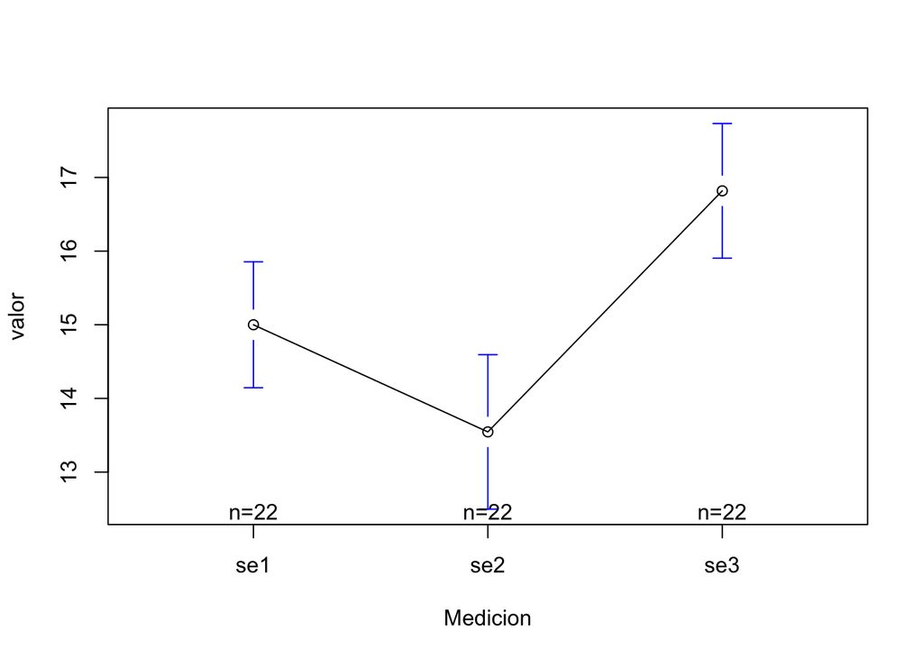

```r
# Hay diferencias entre los 3.
library(gplots)
attach(dataLS)
plotmeans(value ~ variable, xlab="Medicion", ylab = "valor")
```

```r
# Los valores más significativos en cuanto aumento se dieron en SE3". SE3 posee los niveles de autoestima más altos.
```

#### PRUEBAS NO PARAMETRICAS

Hipotesis Nula <- Todas las medias son iguales (no existe aumento) Hipotesis alternativa <- Existe alguna media diferente.

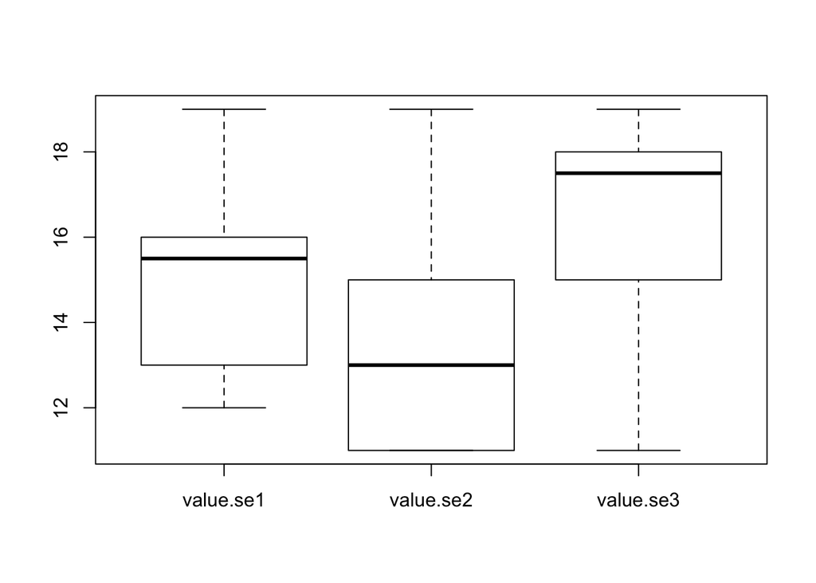

```r
# representamos los datos
x <- reshape(dataLS, v.names = "value", idvar="ID", timevar = "variable", direction = "wide")
boxplot(x[,-1])
```

```r
# se aprecia que en los 3 casos hay diferencias, más significativas en SE3 con el resto.

friedman.test(as.matrix(x[,-1]))
```

```
##
##  Friedman rank sum test
##
## data:  as.matrix(x[, -1])
## Friedman chi-squared = 24.74, df = 2, p-value = 4.245e-06
```

```r
# Viendo el p-valor se concluye que la prueba es significativa. Hay diferencias, se rechaza la hipotesis nula.
# Vemos las diferencias:

pairwise.wilcox.test(dataLS$value, dataLS$variable, p.adjust.method = "bonferroni", exact=F, paired = T)
```

```
##
##  Pairwise comparisons using Wilcoxon signed rank test
##
## data:  dataLS$value and dataLS$variable
##
##     se1     se2
## se2 0.00391 -
## se3 0.00098 0.00082
##
## P value adjustment method: bonferroni
```

```r
# SE3 es el que mayor aumento obtuvo. Mayor diferencia entre SE3 y SE2 y luego SE3 con SE1. SE3 posee los niveles de autoestima más altos.
```

#### PRUEBAS ROBUSTAS

Hipotesis Nula <- Todas las medias son iguales (no existe aumento) Hipotesis alternativa <- Existe alguna media diferente.

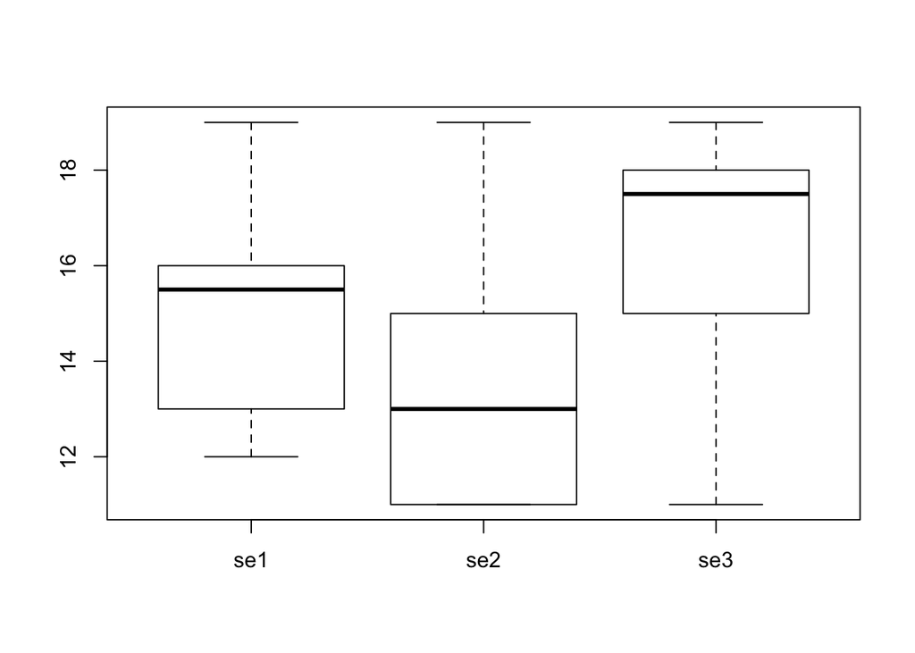

```r
boxplot(value~variable, data= dataLS)
```

```r
rmanova(y = value, groups = variable, blocks = ID)
```

```
## Call:
## rmanova(y = value, groups = variable, blocks = ID)
##
## Test statistic: 21.7707
## Degrees of Freedom 1: 1.42
## Degrees of Freedom 2: 18.46
## p-value: 5e-05
```

```r
# Se obtiene un p-valor menor a 0.05 por lo que rechazamos la hipotesis nula, hay diferencias entre ellos.

rmmcp(y = value, groups = variable, blocks = ID)
```

```
## Call:
## rmmcp(y = value, groups = variable, blocks = ID)
##
##               psihat ci.lower ci.upper p.value p.crit  sig
## se1 vs. se2  1.21429  0.07217  2.35640 0.01195 0.0500 TRUE
## se1 vs. se3 -1.85714 -2.99111 -0.72318 0.00060 0.0169 TRUE
## se2 vs. se3 -3.28571 -5.44949 -1.12194 0.00110 0.0250 TRUE
```

```r
# En todos los casos nos dan valores significativos.Entre SE2 y SE3 es donde obtenemos valores más diferenciados. SE3 posee los niveles de autoestima más altos.
rm(list = ls())
```

## Ejercicio 5

Se quiere evaluar un estudio de gemelos del mismo sexo donde un gemelo ha tenido una condena penal. Se recopiló la siguiente información: si el hermano también había tenido una condena penal y si los gemelos eran gemelos monocigóticos (idénticos) o dicigóticos (no idénticos; Fisher 1962, 1970). Los estudios de gemelos como este se han utilizado a menudo para investigar los efectos de la “naturaleza versus crianza”. Queremos contrastar si la proporción de condenados es mayor para los gemelos monocigóticos que para los dicigóticos.

```r
Convictions <-matrix(c(2, 10, 15, 3), nrow = 2,
                     dimnames = list(c("Dizygotic", "Monozygotic"),c("Convicted", "Not convicted")))
Convictions
```

```
##             Convicted Not convicted
## Dizygotic           2            15
## Monozygotic        10             3
```

#### Siendo p1 monocigóticos y p2 dicigóticos:

Hipotesis Nula <- p1 menor o igual a p2 Hipotesis Alternativa <- p1 mayor que p2

```r
prop.test(Convictions)
```

```
##
##  2-sample test for equality of proportions with continuity
##  correction
##
## data:  Convictions
## X-squared = 10.458, df = 1, p-value = 0.001221
## alternative hypothesis: two.sided
## 95 percent confidence interval:
##  -0.9949783 -0.3081892
## sample estimates:
##    prop 1    prop 2
## 0.1176471 0.7692308
```

```r
# Como p-valor es menor a 0.05 rechazamos la hipotesis nula, por lo que la proporción de monocigóticos convictos es mayor que la de dicigóticos.

rm(list = ls())
```

## Ejercicio 6

Utiliza los datos “infert” para evaluar si existe una relación entre el nivel educativo y el número abortos inducidos. La base de datos “infert“ corresponde a un estudio de caso-control pareado donde la variable Education está formada por 3 categorías (0 = 0-5 años, 1 = 6-11 años, 2 = 12+ años); y la variable number of prior induced abortions también (0 = 0, 1 = 1, 2 = 2 o más abortos inducidos). Interpreta los resultados.

```r
data("infert")
head(infert)
```

```
##   education age parity induced case spontaneous stratum pooled.stratum
## 1    0-5yrs  26      6       1    1           2       1              3
## 2    0-5yrs  42      1       1    1           0       2              1
## 3    0-5yrs  39      6       2    1           0       3              4
## 4    0-5yrs  34      4       2    1           0       4              2
## 5   6-11yrs  35      3       1    1           1       5             32
## 6   6-11yrs  36      4       2    1           1       6             36
```

```r
dim(infert)
```

```
## [1] 248   8
```

```r
# aislamos las columnas con las que trabajar.
datos <- table(infert[c("education", "induced")])
datos
```

```
##          induced
## education  0  1  2
##   0-5yrs   4  2  6
##   6-11yrs 78 27 15
##   12+ yrs 61 39 16
```

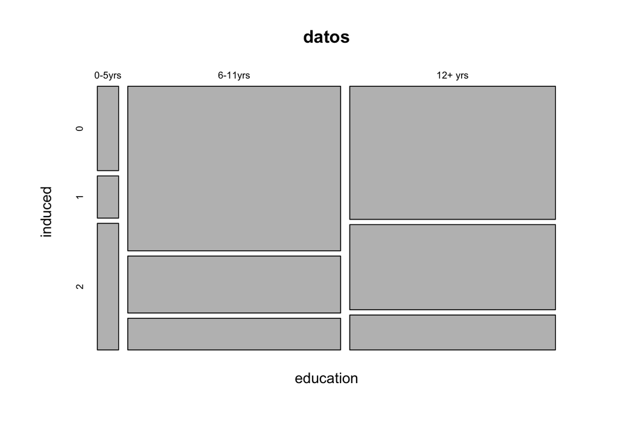

```r
# proporciones para cada una de las variables de educación, mostrando los abortos inducidos.
plot(datos)
```

#### Suponemos:

H0 <- Las variables Education e Induced son independientes. H1 <- Ambas variables son dependientes.

```r
chisq.test(datos)
```

```
##
##  Pearson's Chi-squared test
##
## data:  datos
## X-squared = 16.531, df = 4, p-value = 0.002384
```

```r
# Como p-valor es menor a 0.05 rechazamos la hipotesis nula, por lo que la sí existen dependencia entre las variables de Educación y Abortos inducidos.

# Miramos que grado de asociación existe mediante Medidas de asociación global.
library(vcd)
assocstats(datos)
```

```
##                     X^2 df  P(> X^2)
## Likelihood Ratio 12.992  4 0.0113149
## Pearson          16.531  4 0.0023839
##
## Phi-Coefficient   : NA
## Contingency Coeff.: 0.25
## Cramer's V        : 0.183
```

```r
# Muestra una asocación débil (Se aprecia en la V de Cramer
rm(list = ls())
```